# Mokelumne River

Sadie Gill, Mark Tompkins, Erin Cain

June 18, 2019

## Future Data Improvements

- EBMUD developing new steelhead rearing habitat flow:area relationships (expected January 2019)
- EBMUD developing new Fall Run floodplain rearing habitat flow:area relationships with Mark Gard (expected late 2019)

## Instream Spawning and Rearing Habitat

**Data Sources:** EBMUD 2016 and [CDFW 1991](https://s3-us-west-2.amazonaws.com/cvpiahabitat-r-package/cvpia-sit-model-inputs/Lower+Mokelumne+RIver+Fisheries+Management+Plan%2C+CDFG+1991.pdf)

### Combine Instream Spawning and Rearing Habitat Data

The instream spawning and rearing habitat data described above is combined for use in the DSM in the following format.

| flow_cfs | FR_spawn_wua | FR_fry_wua | FR_juv_wua | ST_spawn_wua | watershed |
| --- | --- | --- | --- | --- | --- |
| 0 | 0.000 | NA | NA | 0.000 | Mokelumne River |
| 100 | NA | 26783.27 | 29606.59 | NA | Mokelumne River |
| 105 | 5662.441 | 26584.44 | 29465.08 | 3969.682 | Mokelumne River |
| 140 | 7016.761 | 25234.03 | 28541.24 | 5167.945 | Mokelumne River |
| 180 | 8240.197 | 23675.02 | 27441.99 | 6462.489 | Mokelumne River |

*…with 47 more rows.*

### Spawning WUA

EBMUD provided a spawning habitat flow:area relationship covering the entire river. For each flow, the area was converted to an area per unit length by dividing the total spawning area by the length of the spawning reach mapped by the SIT.

#### Salmon Spawning WUA Plot

The following plot shows the weighted usable spawning area rate in square feet per thousand feet of river for Fall Run Chinook Salmon (FR). These rates are multiplied by the total spawning reach length mapped by the SIT and applied for the flow in each month in the DSM.

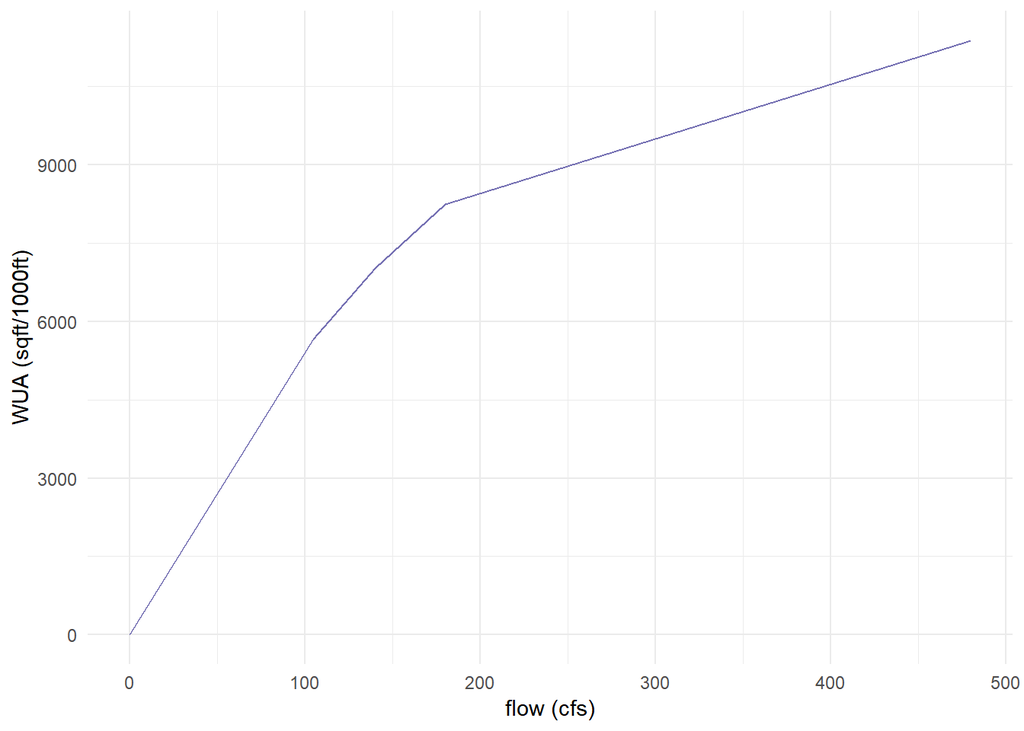

#### Steelhead Spawning WUA Plot

The following plot shows the weighted usable spawning area rate in square feet per thousand feet of river for Steelhead (ST). These rates are multiplied by the total spawning reach length mapped by the SIT and applied for the flow in each month in the DSM.

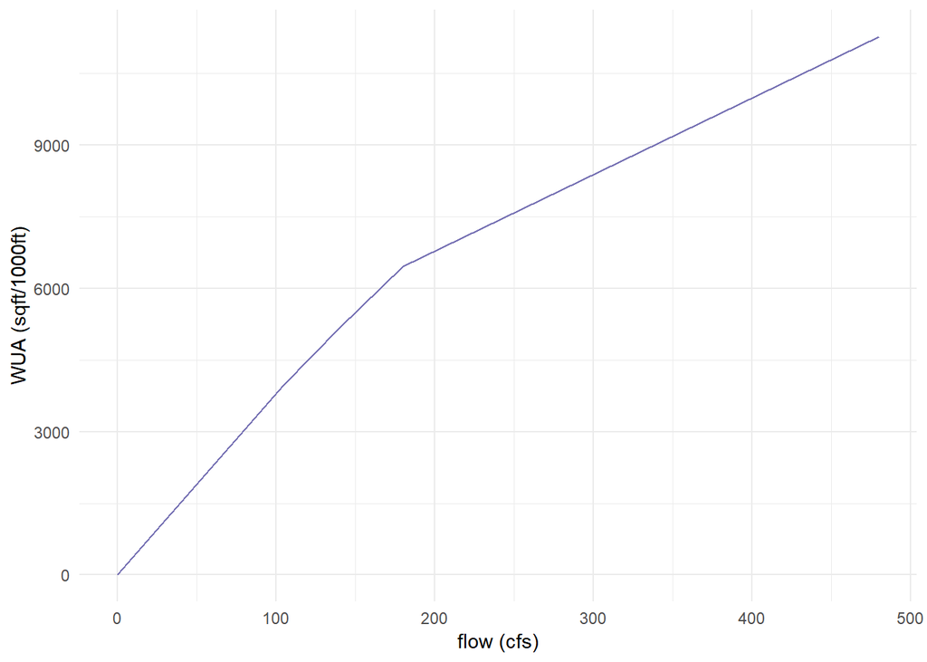

### Rearing WUA Plots

The following plot shows the weighted usable rearing area in square feet per thousand feet of river for Fall Run Chinook Salmon fry and juvenile. These rates are multiplied by the total rearing reach length mapped by the SIT.

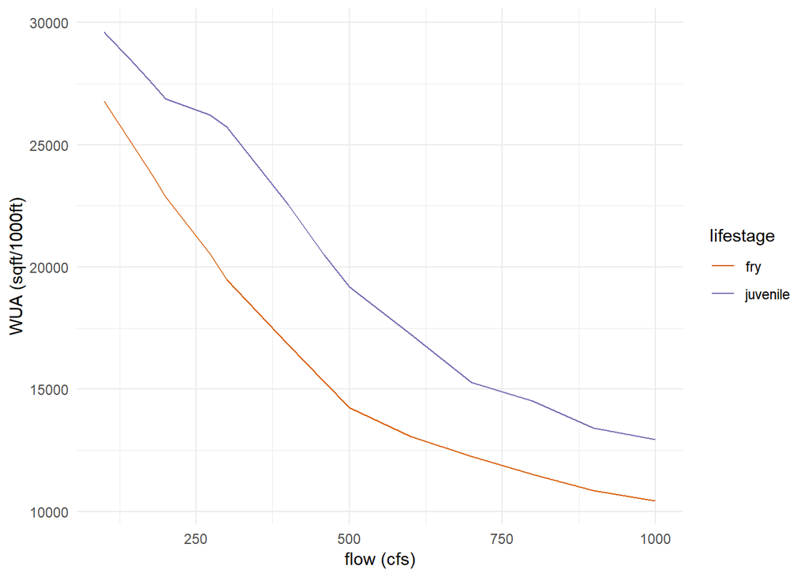

## Floodplain

The flow : floodplain area relationship for the Mokelumne River is based on high resolution (4 square foot cell size) two-dimensional hydraulic modeling completed by EBMUD in 2017 (Technical Memorandum in preparation by Robyn Bilski at EBMUD). The extent of this modeling is from River Mile 62.8 to River Mile 64. All area inundated by flows less than or equal to 400 cfs were considered instream. The inundated area per length from this modeled reach was extrapolated to the entire rearing reach in the Mokelumne River from Camanche Dam downstream to the point of tidal influence. This flow : floodplain area relationship was used for all salmon and steelhead runs in the Mokelumne River. The following table contains the flow : floowplain area relationships used in the DSM.

| flow_cfs | FR_floodplain_acres | SR_floodplain_acres | ST_floodplain_acres | watershed |
| --- | --- | --- | --- | --- |
| 400 | 0.0000 | 0.0000 | 0.0000 | Mokelumne River |
| 800 | 135.4992 | 135.4992 | 135.4992 | Mokelumne River |
| 900 | 160.7151 | 160.7151 | 160.7151 | Mokelumne River |
| 1100 | 203.6763 | 203.6763 | 203.6763 | Mokelumne River |
| 1300 | 239.4405 | 239.4405 | 239.4405 | Mokelumne River |

*…with 2 more rows.*